# Initial analysis

# 1 Background

We have cohort of samples profiled for proteomics, genomics and metylation. We want to create a harmonized clinical file for all these patients.

In regards to proteomics. Samples were profiled ;

1. Psomagen cohort
2. Olink 2023 cohort (Q-13356)
3. Olink 2024 cohort

In addition, some patients were also profiled by genomics (KLK2 SNPs) and methylation.

# 2 Objectives

1. Gather data
2. Clean up clinical data
3. Summary of data

# 3 Pre-processing

## 3.1 Loading packages

```r
library(here)
library(tidyverse)
library(readxl)
library(readr)
library(stringr)

library(tidyverse)
library(ggplot2)
library(VennDiagram)
library(ggvenn)
```

## 3.2 Directories

```r
wd <- list()
wd$main <- here()
wd$data <- file.path(wd$main, "data")
wd$manishData <- file.path(wd$data, "raw/data_fromManish")
wd$d2024 <- file.path(wd$data, "updated_2024")
wd$d2024_npx <- file.path(wd$d2024, "NPX_data")
wd$output <- file.path(wd$main, "output")
wd$script <- file.path(wd$main, "scripts")

wd$outData <- file.path(wd$output, "data")
wd$outCurr <- file.path(wd$output, "01_InitialAnalys")

t.testDir <- file.path(wd$outCurr , "t_test")
dir.create(t.testDir)
```

Create directories

```r
if (!file.exists(wd$outCurr)) {
  dir.create(wd$outCurr)
} else {
  print("Directory already exists")
}
```

```
## [1] "Directory already exists"
```

Load functions

```r
source(file.path(wd$script, "functions.R"))
```

# 4 Objective 1

**Gather data**

## 4.1 Psomagen

There were 2 files provided by Manish, we detail them here and read into R.

1. **E3072_AN00003660_AN00003661_NPX_2022-04-21-columns**

This file is the NPX values from Olink. Samples are listed in the `SampleID` column

```r
# Read the files
dat_NPX <- readxl::read_excel(file.path(wd$d2024_npx, "batch_01_E3072_AN00003660_AN00003661_NPX_2022-04-21-columns.xlsx"))
```

This contains the clinical files of all Proteomics cohort

```r
meta_file <- file.path(file.path(wd$d2024, "clinical_data/Proteomic Project Clinical file 09_10_24_Combined_ID_zaki_edited.xlsx"))
```

### 4.1.1 NPX data

Read the NPX data

**E3072_AN00003660_AN00003661_NPX_2022-04-21-columns**

This file is the NPX values from Olink.

Get Sample ID (listed in the `SampleID` column)

```r
b1_id <- unique(dat_NPX$SampleID)
length(b1_id)
```

```
## [1] 178
```

Find the number of samples not including the internal control

```r
b1_noCtrl <- b1_id[!grepl("SC", b1_id)]
length(b1_noCtrl)
```

```
## [1] 176
```

### 4.1.2 Clinical data

In the Psomagen cohort, some samples were profiled serially. The excel file contains 2 sheets related the Psomagen cohort, sheets 2 & 3.

Sheet 2 contains only the unique patients IDs per row. It contains all the clinical data, eg - surgery, PSA values, tumor stage, date of death…etc.

While Sheet 3 have the same number of rows as the NPX data. In sheet 3, the same patient with multiple timepoints is represented in multiple rows. There is a column `sample_id` that links to the NPX `sampleID`.

```r
ps_clin.1 <- read_xlsx(meta_file, sheet = 3)
```

Synonym sample IDs are provided in sheet 4

```r
ps_clin.2 <- read_xlsx(meta_file, sheet = 4)
```

## 4.2 Olink Q-13356

There were 2 files provided by Manish, we detail them here and read into R.

1. **Q-13356_Kohli_EXTENDED_NPX_2024-03-11**

This file is the NPX values from Olink. Samples are listed in the `SampleID` column

2. The same clinical file as above

This contains the clinical files of Psomagen cohort and Olink Q-13356 cohort

### 4.2.1 NPX data

Read the NPX data. Samples are listed in the `SampleID` column

```r
# Read the files
dat_NPX2 <- readr::read_delim(file.path(wd$d2024_npx, "batch_02_Q-13356_Kohli_EXTENDED_NPX_2024-03-11.csv"), delim = ";")
dat_NPX2 <- readr::read_delim(file.path(wd$d2024_npx, "Re_delivery_Intensity_based/Q-13356_Data Delivery/Q-13356_Kohli_Intensity_EXTENDED_NPX_2024-10-30.csv"), delim = ";")
```

Get Sample ID

```r
b2_id <- unique(dat_NPX2$SampleID)
length(b2_id)
```

```
## [1] 104
```

Find the number of samples not including the internal control

```r
b2_noCtrl <- b2_id[!grepl("CONTROL_SAMPLE|NEG_CTRL|PLATE_CTRL", b2_id)]
length(b2_noCtrl)
```

```
## [1] 88
```

### 4.2.2 Clinical data

In the this Olink Q-13356 cohort, there are no serial samples. Clinical data is contained in sheet 4 & 5. of the excel files.

Sheets 4 & 5 contains contains all the clinical data, eg - surgery, PSA values, tumor stage, date of death…etc. Sheet 4 is limited to the CRPC cohort and sheet 5 is limited to HSPC cohort. There is a column `Sample ID (validation)` that links to the NPX `sampleID`.

```r
q_133_clin.1 <- read_xlsx(meta_file, sheet = 4) %>%
  # Rename columns
  dplyr::rename(sample_id = 'Sample ID (validation)')
n1 <- length(unique(q_133_clin.1$`HCI number`))
n1
```

```
## [1] 45
```

We repeat reading the clinical data of the HSPC cohort

```r
q_133_clin.2 <- read_xlsx(meta_file, sheet = 5) %>%
  # Rename columns
  dplyr::rename(sample_id = 'Sample ID (validation)')
n2 <- length(unique(q_133_clin.2$`HCI Number`))
n2
```

```
## [1] 42
```

Based on the NPX, we have 88 samples. Meanwhile in the clinical file, we have 45 in CRPC and 42 for HSCP. The total in clinical file is 87.

There is one less patient in the clinical sheet.

Clarification was given by Claire

> From: Claire Hanson Claire.Hanson@hci.utah.edu  
> Sent: Thursday, June 20, 2024 9:33 AM.  
> To: Zaki Wilmot zaki.wilmot@hci.utah.edu; Manish Kohli Manish.Kohli@hci.utah.edu; Enos Ampaw Enos.Ampaw@hci.utah.edu  
> Subject: Re: Overlapping files

> Hi Zaki,

> The duplicate sample is 34 and 78 (2021-2165). We used sample ID 34 as one of the bridging samples as well.

> Thanks, Claire

We will keep this in mind when we process the NPX data

## 4.3 Olink Q-15806

### 4.3.1 NPX data

Read the NPX data. Samples are listed in the `SampleID` column

```r
# Read the files
dat_NPX3 <- readr::read_delim(file.path(wd$d2024_npx, "Q-15806_Kohli_NPX_2024-07-29.csv"), delim = ";")
dat_NPX3 <- readr::read_delim(file.path(wd$d2024_npx, "Re_delivery_Intensity_based/Q-15806_Data Delivery/Q-15806_Kohli_EXTENDED_NPX_2024-10-30.csv"), delim = ";")
```

Get Sample ID

```r
b3_id <- unique(dat_NPX3$SampleID)
length(b3_id)
```

```
## [1] 104
```

```r
b3_noCtrl <- b3_id[!is.na(b3_id)]
length(b3_noCtrl)
```

```
## [1] 104
```

### 4.3.2 Clinical data

Two tab of clinical were provided for Olink Q-15806.

The first files details the Olink sampleID and HCI collection id. We read this first, as this is what is currently required

```r
q_158_d <- read_xlsx(meta_file, sheet = 8) %>%
  # Edit column names
  rename(HCI_cID = 'HCI Number',
         sample_id = 'Sample ID',
         Tx_stage = 'Pre/Post Tx?')
```

## 4.4 Match protein IDs

Make a table of proteins and OlinkIDs

```r
d1 <- dat_NPX %>% select(OlinkID, Assay) %>% distinct() %>%
  mutate(ID_assay = paste(OlinkID, Assay, sep="_"))
d2 <- dat_NPX2 %>% filter(!str_detect(Assay, "control")) %>% select(OlinkID, Assay) %>% distinct() %>%
  mutate(ID_assay = paste(OlinkID, Assay, sep="_"))

d_all <- rbind(d1,d2) %>% distinct()


d_all <- d_all %>%
  mutate(inPsom = if_else(ID_assay %in% d1$ID_assay, "Y", "N"),
         inQ1335 = if_else(ID_assay %in% d2$ID_assay, "Y", "N"))

write.csv(d_all, file.path(wd$outCurr, "Proteins_overlap.csv"))
```

We note there are three proteins with mis-match annotation, lets correct this

```r
d_all <- d_all %>%
  mutate(
    Assay = case_when(
      OlinkID == "OID20125" ~ "NT-proBNP",
      OlinkID == "OID20857" ~ "CERT1",
      OlinkID == "OID21084" ~ "WARS1",
      TRUE ~ Assay))

# Create a list of Olink paired with protein ID
df_id_pro <- d_all %>% select(OlinkID, Assay) %>% distinct()

write.csv(df_id_pro, file.path(wd$outCurr, "Olink_assay_table.csv"))
```

# 5 Objective 2

**Clean up clinical data**

We want to combine all data as one df. To make counting and overlapping easier. The unique IDs to merge across these different platforms will be the HCI ID. For the clinical data with mrn & HCI collection ID, we make them into a data frame.

Matt provided us with an updated cohort information. Lets read it in.

```r
df_cohort <- read_xlsx(file.path(wd$d2024, "clinical_data/Cohort_grouping_2024_10_21.xlsx")) %>%
  select(mrn:txt_stat) %>%
  rename(Psomagen = Discovery,
         Q_13356 = Project_2,
         Q_15806 = Project_4)
```

## 5.1 Tally

Lets get a tally of the number of sample in all projects

### 5.1.1 Sample IDs

In the NPX files we are given the ID as “sample_ID”. Lets link the sample ID of the NPX with the sample ID in the clinical data.

```r
# --- Psomagen cohort ---- #
# As all sample ID are numbers. We convert it to numeric. Non-number will give NA
# We stored the Psomagen NPX IDs - b1_noCtrl
d1.1 <- data.frame(
  sample_id_psom = as.numeric(b1_noCtrl)
)
# Extract the HCI collection ID from clinical files
d1.2 <- data.frame(
  HCI_cID = ps_clin.1$`collection_id-hci_id`,
  sample_id_psom = as.numeric(ps_clin.1$sample_id)
)
# Merge the two
d1 <- left_join(d1.1, d1.2)
# Santiy check to ensure all NPX data have clinical data, value needs to be 0
sum(is.na(d1$HCI_cID))
```

```
## [1] 0
```

```r
# --- Olink Q-13356 cohort ---- #
# We stored the Q-13356 NPX IDs - b2_noCtrl
d2.1 <- data.frame(
  sample_id_Q13356 = as.numeric(b2_noCtrl)
)
# Extract the HCI collection ID from clinical files
# The clinical file also contained a record of a supposed psomagen ID
d2.2 <- data.frame(
  HCI_cID = c(q_133_clin.1$`HCI number`, q_133_clin.2$`HCI Number`),
  sample_id_Q13356 = as.numeric(c(q_133_clin.1$sample_id, q_133_clin.2$sample_id)),
  sample_id_psom_2 = as.numeric(c(q_133_clin.1$`Sample Id (previous analysis)`, q_133_clin.2$`Sample ID (previous analysis)`))
)
# Merge the two
d2 <- left_join(d2.1, d2.2)
# Santiy check to ensure all NPX data have clinical data, value needs to be 0
sum(is.na(d2$HCI_cID))
```

```
## [1] 1
```

We noted here that there is one sample missing a clinical ID. We go back to the email from Claire that mentioned the sample “2021-2165” was profiled twice and should have the assigned sample_id : 34 and 78

```r
filter(d2, is.na(HCI_cID))
```

```
##   sample_id_Q13356 HCI_cID sample_id_psom_2
## 1               78    <NA>               NA
```

We see sample ID 78 is missing clinical data. So we just exclude sample 78 for now

```r
d2 <- d2 %>%
  filter(!sample_id_Q13356 == 78)
```

Repeat for Q-15806

```r
d3 <- q_158_d %>%
  select(HCI_cID, sample_id) %>%
  mutate(sample_id = as.numeric(sample_id)) %>%
  rename(sample_id_Q15806 = sample_id)
```

Finally, combine all sample IDs

```r
# Combine all the sample IDs
df_meta_f <- df_cohort %>%
  left_join(d1) %>%
  left_join(d2) %>%
  left_join(d3)
write.csv(df_meta_f, file.path(wd$outCurr, "MetaData_Proteomics.csv"))
```

## 5.2 Num samples

```r
# Step 1: Summarize the data (count samples for each cohort and txt_stat combination)
summary_df <- df_meta_f %>%
  mutate(txt_stat = gsub("[1-2]", "", txt_stat),
         txt_stat = gsub("post", "Post", txt_stat)) %>%
  group_by(cohort, txt_stat)

pr1.1 <- print(paste0("Num of patients in All is ", length(unique(summary_df$mrn))))
```

```
## [1] "Num of patients in All is 217"
```

```r
pr1.2 <- print(paste0("Num of samples in All is ", length(unique(summary_df$HCI_cID))))
```

```
## [1] "Num of samples in All is 312"
```

```r
summary_df1 <- summary_df %>%
  summarise(count = n(), .groups = 'drop') %>%
  # Create a new column that combines cohort and txt_stat
  mutate(cohort_txt_stat =
           paste(cohort, txt_stat, sep = "_"),
         cohort_txt_stat = factor(cohort_txt_stat, levels=c(
           "A_Pre", "A_Post", "B_Pre", "B_Post", "C_D_Pre", "C_D_Post"
         ))) %>%
  mutate(Batch = "01_All_cohort")


# Psomagen only
summary_df <- df_meta_f %>%
  filter(Psomagen == "Y") %>%
  mutate(txt_stat = gsub("[1-2]", "", txt_stat),
         txt_stat = gsub("post", "Post", txt_stat))
pr2.1 <- print(paste0("Num of patients in Discovery is ", length(unique(summary_df$mrn))))
```

```
## [1] "Num of patients in Discovery is 108"
```

```r
pr2.2 <- print(paste0("Num of samples in Discovery is ", length(unique(summary_df$HCI_cID))))
```

```
## [1] "Num of samples in Discovery is 176"
```

```r
summary_df2 <- summary_df %>%
  group_by(cohort, txt_stat) %>%
  summarise(count = n(), .groups = 'drop') %>%
  # Create a new column that combines cohort and txt_stat
  mutate(cohort_txt_stat =
           paste(cohort, txt_stat, sep = "_"),
         cohort_txt_stat = factor(cohort_txt_stat, levels=c(
           "A_Pre", "A_Post", "B_Pre", "B_Post", "C_D_Pre", "C_D_Post"
         ))) %>%
  mutate(Batch = "02_Discovery")


# Olinks only
summary_df <- df_meta_f %>%
  filter(!Psomagen == "Y") %>%
  filter(Q_13356 == "Y" | Q_15806 == "Y") %>%
  mutate(txt_stat = gsub("[1-2]", "", txt_stat),
         txt_stat = gsub("post", "Post", txt_stat)) %>%
  group_by(cohort, txt_stat)

pr3.1 <- print(paste0("Num of patients in Validation is ", length(unique(summary_df$mrn))))
```

```
## [1] "Num of patients in Validation is 109"
```

```r
pr3.2 <- print(paste0("Num of samples in Validation is ", length(unique(summary_df$HCI_cID))))
```

```
## [1] "Num of samples in Validation is 136"
```

```r
summary_df3 <- summary_df %>%
  summarise(count = n(), .groups = 'drop') %>%
  # Create a new column that combines cohort and txt_stat
  mutate(cohort_txt_stat =
           paste(cohort, txt_stat, sep = "_"),
         cohort_txt_stat = factor(cohort_txt_stat, levels=c(
           "A_Pre", "A_Post", "B_Pre", "B_Post", "C_D_Pre", "C_D_Post"
         ))) %>%
  mutate(Batch = "03_Validation")


# Step 1: Summarize the data (count samples for each cohort and txt_stat combination)
summary_df <- df_meta_f %>%
  mutate(txt_stat = gsub("[1-2]", "", txt_stat),
         txt_stat = gsub("post", "Post", txt_stat)) %>%
  filter(txt_stat == "Pre") %>%
  group_by(cohort, txt_stat)

pr4.1 <- print(paste0("Num of patients in All is ", length(unique(summary_df$mrn))))
```

```
## [1] "Num of patients in All is 155"
```

```r
pr4.2 <- print(paste0("Num of samples in All is ", length(unique(summary_df$HCI_cID))))
```

```
## [1] "Num of samples in All is 166"
```

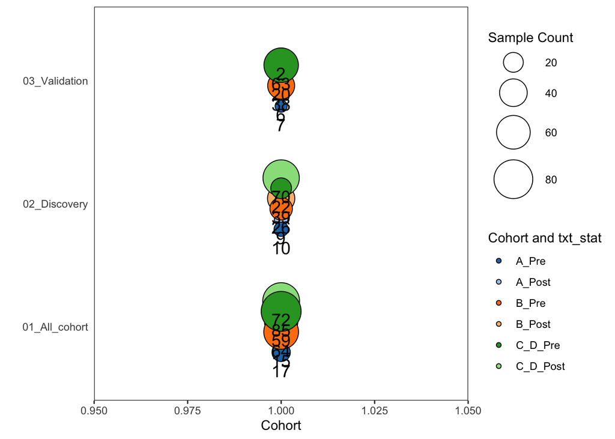

```r
summary_df4 <- summary_df %>%
  summarise(count = n(), .groups = 'drop') %>%
  # Create a new column that combines cohort and txt_stat
  mutate(cohort_txt_stat =
           paste(cohort, txt_stat, sep = "_"),
         cohort_txt_stat = factor(cohort_txt_stat, levels=c(
           "A_Pre", "A_Post", "B_Pre", "B_Post", "C_D_Pre", "C_D_Post"
         ))) %>%
  mutate(Batch = "04_All_baseline")



summary_df_all <- rbind(summary_df1, summary_df2, summary_df3)

# Custom colors: you can choose shades inspired by Tableau colors
custom_colors <- c(
  "A_Pre" = "#1f77b4", "A_Post" = "#aec7e8",  # Blue shades
  "B_Pre" = "#ff7f0e", "B_Post" = "#ffbb78",  # Orange shades
  "C_D_Pre" = "#2ca02c", "C_D_Post" = "#98df8a"  # Green shades
)

# Updated plot
p1 <- ggplot(summary_df_all, aes(x = 1, y = Batch, size = count, fill = cohort_txt_stat)) +
  geom_point(shape = 21, color = "black", position=position_dodge(width=0.5)) +  # Create circles with black border
  geom_text(aes(label = count), vjust = 2, size = 5, position=position_dodge(width=0.5)) +  # Add text underneath circles
  scale_size_area(max_size = 15) +  # Adjust circle sizes
  scale_fill_manual(values = custom_colors) +  # Set custom colors
  labs(x = "Cohort", y = "", fill = "Cohort and txt_stat", size = "Sample Count") +  # Label x-axis and legend
  theme_bw() +  # Clean background
  theme(legend.position = "right", axis.ticks.y = element_blank(),
        panel.grid = element_blank())
ggsave(p1, file=file.path(wd$outCurr, "Treatment_breakdown.pdf"), height = 5, width = 7)
p1
```

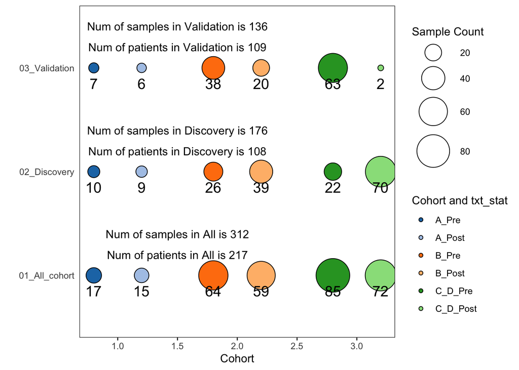

```r
# Plot without overlaps
p2 <- ggplot(summary_df_all,
             aes(x = c(
               rep(c(1.2, 0.8,
                     2.2, 1.8,
                     3.2, 2.8),3)
               ),
                 y = Batch,
                 size = count, fill = cohort_txt_stat)) +
  geom_point(shape = 21, color = "black") +  # Create circles with black border
  geom_text(aes(label = count), vjust = 2, size = 5) +  # Add text underneath circles
  scale_size_area(max_size = 15) +  # Adjust circle sizes
  scale_fill_manual(values = custom_colors) +  # Set custom colors
  labs(x = "Cohort", y = "", fill = "Cohort and txt_stat", size = "Sample Count") +  # Label x-axis and legend
  theme_bw() +  # Clean background
  theme(legend.position = "right", axis.ticks.y = element_blank(),
        panel.grid = element_blank(),
        scale_y_discrete(expand = expansion(add = c(1, 1)))) +
  annotate("text", x = 1.5, y = 1.2,
           label = pr1.1) +
  annotate("text", x = 1.5, y = 1.4,
           label = pr1.2) +
  annotate("text", x = 1.5, y = 2.2,
           label = pr2.1) +
  annotate("text", x = 1.5, y = 2.4,
           label = pr2.2) +
  annotate("text", x = 1.5, y = 3.2,
           label = pr3.1) +
  annotate("text", x = 1.5, y = 3.4,
           label = pr3.2) +
  NULL
p2
```

```r
ggsave(p2, file=file.path(wd$outCurr, "Sample_numbers_discovery_validation.pdf"), height = 5, width = 12)
```

## 5.3 Longtidudinal

Lets plot the distribution of samples. To see how many are longtiduinal samples. Ie - same mrn, profiled pre- and post- treatment.

```r
# Identify patients groups ;
# Group 1 - mrn that occurs 1x
# Group 2 - mrn that occurs 2x
#   -2B - mrn 2x in cohort B
#   -2C - mrn 2x in cohort C_D
#   -2D - mrn 1x in cohort B & 1x in cohort C_D
# Group 3 - mrn that occurs 3x
#df_meta_f_ori <- df_meta_f
df_meta_f <- df_meta_f %>%
  mutate(txt_stat = case_when(txt_stat == "post" ~ "Post",
                              txt_stat == "Pre2" ~ "Pre",
                              txt_stat == "Post2" ~ "Post",
                              TRUE ~ txt_stat))

df_tally <- df_meta_f

df_tally_tmp <- df_tally %>%
  select(mrn, HCI_cID, cohort) %>% distinct()

mrn_counts <- df_tally_tmp %>%
  group_by(mrn, cohort) %>%
  summarise(count = n(), .groups = 'drop') %>%
  pivot_wider(names_from = cohort, values_from = count, values_fill = 0)

tot_counts <- df_meta_f %>%
  group_by(mrn) %>%
  summarise(total_observations = n())

mrn_counts <- mrn_counts %>% left_join(tot_counts)
group_1_mrns <- mrn_counts %>% filter(total_observations == 1) %>% pull(mrn)
group_2_mrns <- mrn_counts %>% filter(total_observations == 2)
group_2_cohort_B <- group_2_mrns %>% filter(B == 2) %>% pull(mrn)
group_2_cohort_C <- group_2_mrns %>% filter(C_D == 2) %>% pull(mrn)
group_2_mrns_set2 <- group_2_mrns %>% filter(B == 1 & B == 1) %>% pull(mrn)

# -- Group 2---
df_group2 <- df_meta_f %>%
  filter(mrn %in% group_2_cohort_B) %>%
  select(mrn, HCI_cID, cohort, txt_stat) %>% arrange(mrn, cohort, txt_stat)


# Making a function, to avoid repetition
# Define a function that processes a cohort
process_cohort <- function(df_meta_f, cohort_mrns, prefix, start_group) {
  # Step 1: Filter and arrange
  df_cohort <- df_meta_f %>%
    filter(mrn %in% cohort_mrns) %>%
    select(mrn, HCI_cID, cohort, txt_stat) %>%
    arrange(mrn, cohort, txt_stat)

  # Step 2: Create the pattern for each mrn
  df_cohort <- df_cohort %>%
    group_by(mrn) %>%
    arrange(cohort, txt_stat) %>%
    mutate(pattern = paste(cohort, txt_stat, collapse = "-")) %>%
    ungroup()

  # Step 3: Assign groups based on unique patterns
  unique_patterns <- df_cohort %>%
    distinct(pattern) %>%
    mutate(group = paste0(prefix, LETTERS[start_group + row_number() - 1]))

  # Step 4: Merge group information back
  df_cohort <- df_cohort %>%
    left_join(unique_patterns, by = "pattern")

  # Return the dataframe and the last group number used
  df_cohort_tmp <- df_cohort %>% select(mrn, group) %>% distinct()
  last_group <- start_group + nrow(unique_patterns) - 1

  list(df_cohort_tmp = df_cohort_tmp, last_group = last_group)
}

# Process Group 2B (group_2_cohort_B)
result_B <- process_cohort(df_meta_f, group_2_cohort_B, "Group 2", 1)

# Process Group 2C starting from the next group after Group 2B
result_C <- process_cohort(df_meta_f, group_2_cohort_C, "Group 2", result_B$last_group + 1)

result_CD <- process_cohort(df_meta_f, group_2_mrns_set2, "Group 2", result_C$last_group + 1)

# Combine the results
df_group2_combined <- bind_rows(result_B$df_cohort_tmp, result_C$df_cohort_tmp, result_CD$df_cohort_tmp)


# ---- Group 3 ---- #
# Step 1: Get unique combinations of mrn, cohort, and txt_stat
group_4_mrns <- mrn_counts %>% filter(total_observations == 3) %>% pull(mrn)
df_group4 <- df_meta_f %>%
  filter(mrn %in% group_4_mrns) %>%
  select(mrn, HCI_cID, cohort, txt_stat) %>% arrange(mrn, cohort, txt_stat)


# data_labeled <- df_group4 %>%
#   group_by(mrn, txt_stat) %>%
#   mutate(txt_stat = ifelse(row_number() == 1, txt_stat, paste0(txt_stat, row_number()))) %>%
#   ungroup()


# Step 1: Create a unique pattern by combining cohort and txt_stat for each mrn
# This creates a pattern for each mrn's cohort-txt_stat combination
df_group4 <- df_group4 %>%
  group_by(mrn) %>%
  arrange(cohort, txt_stat) %>%  # Ensure consistent order
  mutate(pattern = paste(cohort, txt_stat, collapse = "-")) %>%
  ungroup()

# Step 2: Assign groups based on unique patterns
# We create a lookup table where each unique pattern is assigned a group
unique_patterns <- df_group4 %>%
  distinct(pattern) %>%
  mutate(group = paste0("Group 3", LETTERS[row_number()]))


# Step 3: Merge the group information back into the original data
df_group4 <- df_group4 %>%
  left_join(unique_patterns, by = "pattern")
df_group4_tmp <- df_group4 %>% select(mrn, group) %>% distinct()

dat_group <- data.frame(
  mrn = c(group_1_mrns,
          df_group2_combined$mrn,
          df_group4_tmp$mrn),
  group = c(
    rep("Group 1", each=length(group_1_mrns)),
    df_group2_combined$group,
    df_group4_tmp$group)
)

data <- df_meta_f %>%
  #select(mrn, HCI_cID, cohort, txt_stat) %>% distinct() %>%
  left_join(dat_group)
# Label consequtive pre or post
data <- data %>%
  group_by(mrn, txt_stat) %>%
  mutate(txt_stat = ifelse(row_number() == 1, txt_stat, paste0(txt_stat, row_number()))) %>%
  ungroup() %>%
  mutate(txt_stat = factor(txt_stat, levels=c("Pre", "Pre2", "Post", "Post2")))

df_pre_post <- data
df_pre_post_tmp <- df_pre_post %>%
  dplyr::rename(SampleID = sample_id_psom) %>%
  select(cohort, SampleID, txt_stat) %>%
  mutate(SampleID = as.character(SampleID)) %>%
  distinct()

data2 <- data %>% group_by(group, cohort, txt_stat) %>%
  arrange(group) %>%
  summarize(count = n()) %>%
  mutate(group = factor(group, levels = (unique(group))))
```

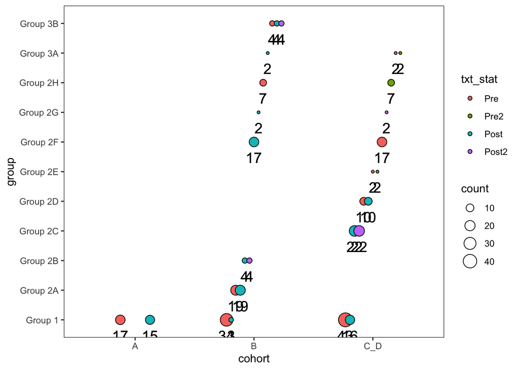

```r
ggplot(data2, aes(x=cohort, y=group, size=count, fill=txt_stat)) +
  geom_point(shape = 21, color = "black", position=position_dodge(width=0.5)) +
  geom_text(aes(label = count), vjust = 2, size = 5, position=position_dodge(width=0.5)) +  # Add text underneath circles
  theme_bw() +  # Clean background
  theme(legend.position = "right", panel.grid = element_blank()) +
  geom_text(aes(label = count), vjust = 2, size = 5, position=position_dodge(width=0.5)) +  # Add text underneath circlesNULL
  NULL
```

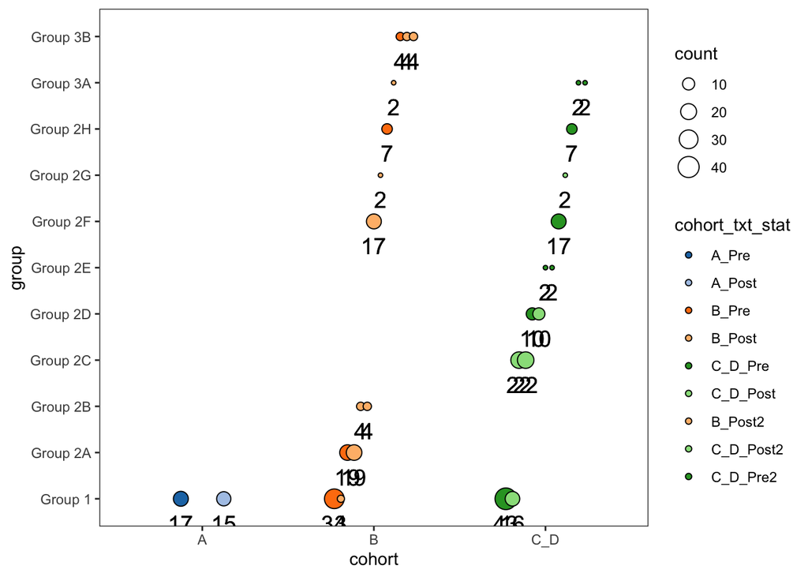

```r
# Custom colors
# Create a new column that combines cohort and txt_stat
data2 <- data2 %>%
  mutate(cohort_txt_stat =paste(cohort, txt_stat, sep = "_"),
         cohort_txt_stat = factor(cohort_txt_stat, levels=unique(cohort_txt_stat)))

# Custom colors: you can choose shades inspired by Tableau colors
custom_colors <- c(
  "A_Pre" = "#1f77b4", "A_Post" = "#aec7e8",  # Blue shades
  "B_Pre" = "#ff7f0e", "B_Post" = "#ffbb78", "B_Post2" = "#ffbb78", # Orange shades
  "C_D_Pre" = "#2ca02c", "C_D_Pre2" = "#2ca02c",
  "C_D_Post" = "#98df8a",  "C_D_Post2" = "#98df8a" # Green shades
)

ggplot(data2, aes(x=cohort, y=group, size=count, fill=cohort_txt_stat)) +
  geom_point(shape = 21, color = "black", position=position_dodge(width=0.5)) +
  geom_text(aes(label = count), vjust = 2, size = 5, position=position_dodge(width=0.5)) +  # Add text underneath circles
  theme_bw() +  # Clean background
  scale_fill_manual(values = custom_colors) +  # Set custom colors
  theme(legend.position = "right", panel.grid = element_blank()) +
  geom_text(aes(label = count), vjust = 2, size = 5, position=position_dodge(width=0.5)) +  # Add text underneath circlesNULL
  NULL
```

```r
p2 <-
ggplot(data2, aes(x=cohort, y=group, size=count, fill=txt_stat)) +
  geom_point(shape = 21, color = "black", position=position_dodge(width=0.5)) +
  scale_size_area(max_size = 15) +  # Adjust circle sizes
  geom_text(aes(label = count), vjust = 2, size = 5, position=position_dodge(width=0.5)) +  # Add text underneath circles
  theme_bw() +  # Clean background
  scale_fill_manual(values = c("Pre" = "lightblue", "Pre2" = "lightblue",
                               "Post" = "orange", "Post2"= "orange")) +  # Set fill colors
  theme(legend.position = "right", panel.grid = element_blank()) +
  geom_text(aes(label = count), vjust = 2, size = 5, position=position_dodge(width=0.5)) +  # Add text underneath circlesNULL
  NULL


ggsave(p2, file=file.path(wd$outCurr, "Treatment_grouping_pattern_updated.pdf"), height = 5, width = 12)

write.csv(data, file.path(wd$outCurr, "Treatment_grouping_pattern_updated.csv"))
```

# 6 Save objects

```r
save(
  dat_NPX, dat_NPX2, dat_NPX3,
  meta_file, df_meta_f, df_id_pro, df_pre_post,
  file = file.path(wd$outData, "01_Metadata.Rdata"))
```